```python
from display_images import display_2_imgs, display_3_imgs, display_4_imgs, show_prediction
import os
os.chdir("../../")
```

# *tabOCR* project

## Temat

### Rozpoznawanie oraz ekstrakcja struktury danych tabelarycznych ze zdjęć.

### Skład:

- Dominik Falkiewicz
- Dominik Horwat

## Cel:

Automatyczne odtworzenie struktury tabeli na podstawie jej zdjęcia. Wynikiem jest plik `.csv/.xlsx` zawierajacy odtworzoną strukturę (kolumny, wiersze) oraz zawartość (tekst, liczby). Zadanie podzielone jest na 3 etapy. Etap 1 i etap 2 realizują różne zadania i wymagają uzycia 2 różnych modeli.

Etapy:

- etap 1: rozpoznanie struktury tabelki - podział na kolumny/wiersze/komórki (ANN),
- etap 2: ekstrakcja danych tekstowych (ANN),
- etap 3: odtworzenie struktury tabelki - plik `.csv/.xlsx`.

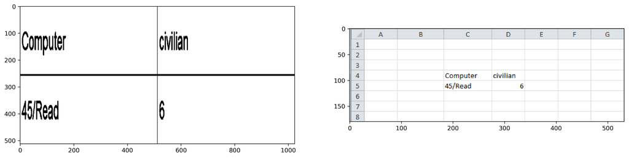

```python
display_2_imgs("notebooks/summary/images/table_xlsx_image.png", "notebooks/summary/images/table_xlsx.png")
```

## Dane

Dane zostały sztucznie wygenerowane wykorszystując Python'a (biblioteka `excel2img`) oraz Excel'a (wykorzystywany pośrednio, przez bibliotekę `excel2img`). Dzięki temu ilość wygenerowanych danych może być dowolna. Generator zapewnia tworzenie różnorodnych zestawów danych. Tabela jest definiowana przez zestaw parametrów. Każdy z parametrów określających dana tabelę jest wybierany losowo. Poniżej wymienona jest większość z zastosowanych parametrów definiujących tabelę:

- liczba kolumn,
- liczba wierszy,
- szerokość kolumn,
- wysokośc wierszy,
- rozmiar i rodzaj czcionki,
- rodzaj, rozmiar, czy istnieje (jest lub nie) obramowania,
- zawartość (tekst, liczby, tekst/liczby),
- długość wyrazów, liczby całkowite/rzeczywiste,
- itp.

Przyjeto równiez następujące założenia upraszczające model danych:

- brak scalonych komórek,
- tekst wyrównany do lewej strony,
- jednolinijkowy tekst w ramach komórki/wiersza,
- obraz binarny (tekst oraz obramowanie, jeśli istnieje, czarne).

Generator (ze względu na złożoność zagadnienia) tworzy następujące elementy pojedynczego zestawu danych:

- tabela - obraz (xlsx/csv),
- tabela - obraz (png),
- maska binarna - obraz; pozycje tekstu w ramach komórek (png),
- maska binarna - obraz; pozycje tekstu w ramach kolumn (png),
- maska - obraz; pozycje kolumn (png),
- maska - obraz; pozycje komórek (png),
- w ramach danej tabeli:
  - kolumny - obraz każdej z kolumn (png),
  - kolumny - tekst każdej z kolumn (json)
  - komórki - obraz każdej z komórek (png),
  - komórki - tkest każdej z komórek (json).

Przykładowy zestaw danych:

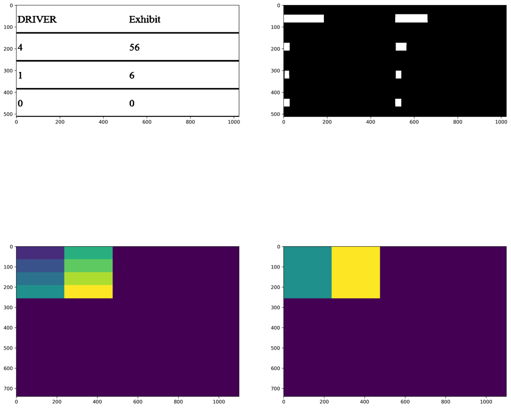

```python
display_4_imgs("notebooks/summary/images/0_table_img.png", "notebooks/summary/images/0_table_mask.png",
               "notebooks/summary/images/mask_cell.png", "notebooks/summary/images/mask_column.png")
```

## Model

### Etap 1:

#### Definicja problemu:

Celem etapu pierwszego jest rozpoznanie struktury tabelki na podstawie jej zdjęcia. W rzeczywistości problem sporwadza sie do odpowiedniego podziału tabelki na kolumny oraz komórki, co pozwoli zrelaizować następujące zadania. Po pierwsze, pozwoli wyekstrahować "jednostki atomowa" (w tym przypadku komórka) zawierające tekst, które będą inputem do etapu 2. Po drugie, pozwoli jednoznacznie zdefiniować przynależność danej komórki do danej kolumny podczas odtwarzania struktury tabeli.

Zadanie można sklasyfikować jako problem segmentacji semantycznej. Polega ona na klasyfikowaniu każdego piksela na obrazie do wstępnie zdefiniowanej ilości klas (2 w przypadku klasyfikacji binarnej).

**a) Pozycje tekstu w tabelce**

#### Rozwiązanie/implementacja

- zadanie: detekcja miejsc występowania tekstu (binarna),
- rodzaj sieci: sieć konwolucyjna o strukturze autoenkodera z skip-connections,
- input: obraz tabelki (`.png`/`np.array`),
- output: maska binarna (`np.array`) określająca pozycję każdej komórki (tj. tekstu) w tabeli,
- funkcja kosztu: `binary crossentropy`

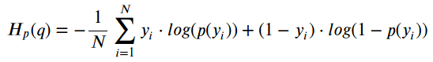

```
gdzie:
- y - etykieta/label (1 dla pikseli zawierających tekst i 0 dla pozostałych),
- p(y) - przewidywane prawdopodobieństwo znalenzienia piksela zawierającego tekst dla wszystkich N punktów
```

- hiperparametry (i inne):
  - learning rate: **0.001**,
  - liczba klas: **2**,
  - ilość epok: **15**,
  - rozmiar obrazów: $512\times1024$,
  - rozmiar batch'a: **4**,
  - ilośc kroków w epoce: **1000**,
  - rozmiar danych:
    - zbiór treningowy: **4000**,
    - zbiór walidacyjny: **1000**,
    - zbiór testowy: **1000**.
- miara dokładności: **Intersection-Over-Union (Jaccard Index)**; $IoU$ to stosunek części wspólnej obrazu (piksele wspólne dla obu obszarów) będącego output'em sieci a tzw. 'ground truth' podzielony przez sumę tych obszarów (wszystkie piksele). Zakres $IoU$ wynosi 0–1 (0–100%).

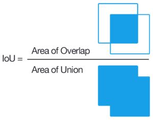

source: wikipedia.com

Para danych wejściowych i wyjściowych:

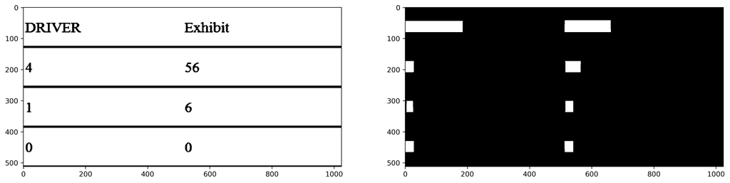

```python
display_2_imgs("notebooks/summary/images/0_table_img.png", "notebooks/summary/images/0_table_mask.png")
```

**Architektura CNN**

Wykorzystano architekturę type enkoder-dekoder z wykorzystaniem skip-connections, aby nie utracić niskopoziomowych informacji o obrazie (np. krawędzi). Użyta architektura wygląd następująco:

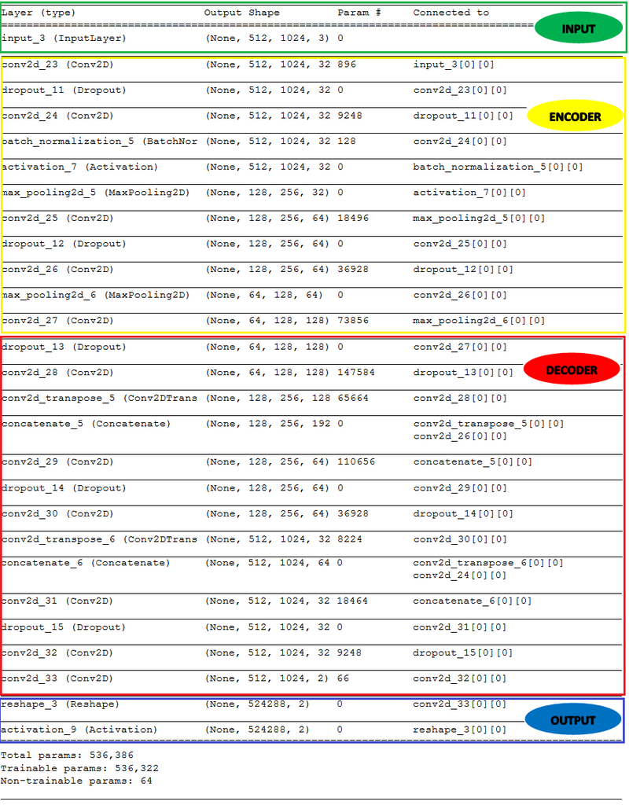

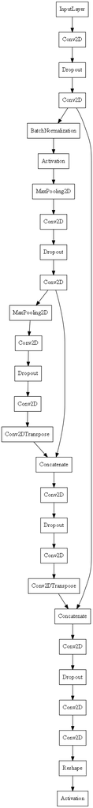

### Wyniki

#### Miary dokładności:

Wynik treningu:

- `loss: 0.0128`
- `mean_iou: 0.8921`
- `val_loss: 0.0129`
- `val_mean_iou: 0.8925`

Wyniki testu:

- `loss: 0.01208`
- `mean_iou: 0.9021`

#### Przykładowe rezultaty predykcji

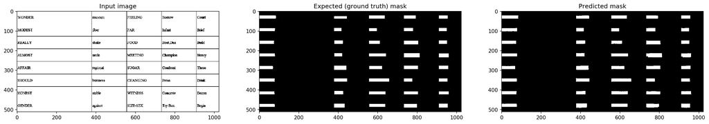

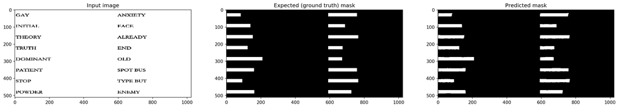

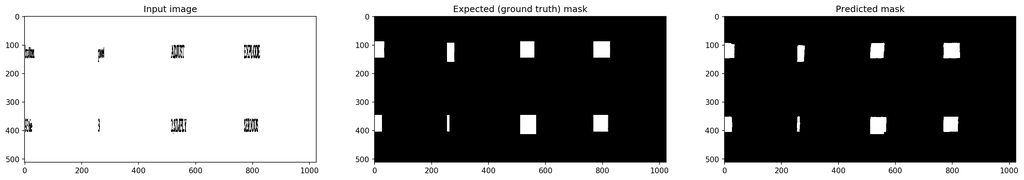

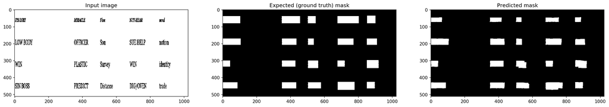

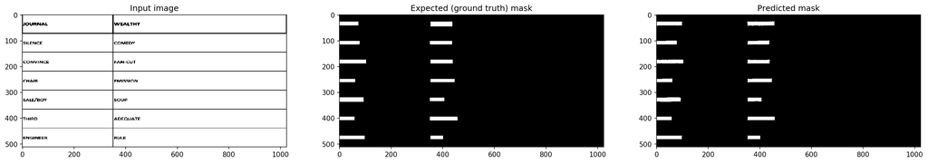

```python
show_prediction("model_table_cells_binary.h5", model_type="cells")
```

**b) Podział na kolumny**

#### Rozwiązanie/implementacja

- zadanie: datekcja miejsc występowania kolumn (binarna),
- rodzaj sieci: sieć konwolucyjna o strukturze autoenkodera z skip-connections,
- input: obraz tabelki (`.png`/`np.array`),
- output: maska binarna (`np.array`) określająca pozycję każdej kolumny w tabeli,
- funkcja kosztu: `binary crossentropy`
- hiperparametry (i inne):
  - learning rate: **0.001**,
  - liczba klas: **2**,
  - ilość epok: **15**,
  - rozmiar obrazów: $512\times1024$,
  - rozmiar batch'a: **4**,
  - ilośc kroków w epoce: **1000**,
  - rozmiar danych:
    - zbiór treningowy: **4000**,
    - zbiór walidacyjny: **1000**,
    - zbiór testowy: **1000**.
- miara dokładności: Intersection-Over-Union (Jaccard Index).

Para danych wejściowych i wyjściowych:

[figure not shown]

```python
display_2_imgs("notebooks/summary/images/0_table_img.png", "notebooks/summary/images/0_table_mask.png")
```

**Architektura CNN**

Jak w punkcie 1 a).

### Wyniki

#### Miary dokładności:

Wyniki treningu:

- loss: 0.1312
- mean_iou: 0.7961
- val_loss: 0.1323
- val_mean_iou: 0.7962

#### Przykładowe rezultaty predykcji

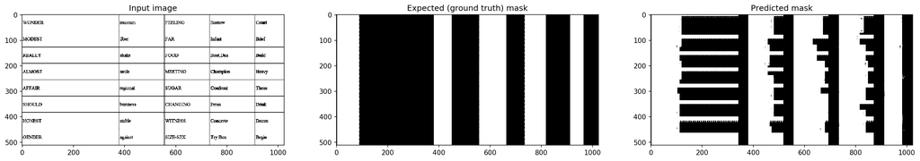

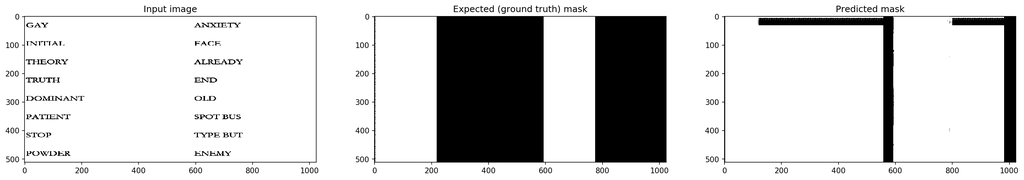

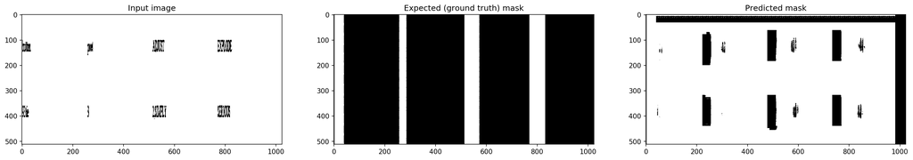

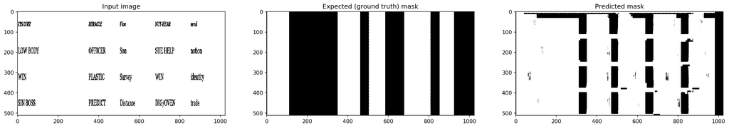

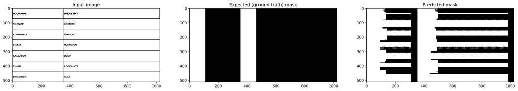

```python
show_prediction("model_table_columns_binary.h5", model_type="columns")
```

### Etap 2:

#### Definicja problemu:

Celem etapu drugiego jest tzw. optyczne rozpoznawanie znaków (ang. OCR - optical character recognition), czyli ekstrakcja tekstu z obrazu. W tym przypadku obraz będzie zawierał tekst danego elementu tabelki (np. komórki), wyekstrahowanym przez pierwszy model.

#### Rozwiązanie/implementacja

- zadanie: ekstrakcja tekstu z obrazu (fragmentu tabeli),
- rodzaj sieci: rekurencyjna sieć konwolucyjna (RCNN),
- input: obraz fragmentu tabelki zawierający tekst (`.png`/`np.array`),
- output: ciąg znaków/lista znaków (`string`) odczytanych z obrazu,

**TBC.**

## Podsumowanie

### Wnioski

- problem ekstrakcji struktury tabeli jest nietrywialny,
- niemniej jednak testy pokazują, że problem jest rozwiązywalny,
- zastosowanie segmentacji semantycznej z klasyfikacją binarną sprawdza się dobrze,
- szukanie pozycji tekstu wydaję się być dobrym pomysłem,
- podział na kolumny wydaje się być zadaniem bardziej skomplikowanym niż szukanie pozycji tekstu; należałoby zastanowić się nad innym podejściem do problemu odtworzenias truktury tabeli,
- najważniejszym etapem jest przygotowanie danych; dobrze przygotowane i zweryfikowane dane pozwalają zaoszczędzić mnóstwo czasu spędzonego nad debugowaniem oraz nerwów...,
- etap przygotowania danych był najbardziej praco- oraz czasochłonną czynnością.

### Trudności/lepiej unikać

- zastosowanie klasyfikacji z wieloma kategoriami nie powiodło się, nawet dla prostszego zestawu danych, bez względu na rodzaj zadania postawionego przed ANN (znalezienie pozycji tekstu, podział na kolumny lub komórki),
- próba segmentacji wolnych przestrzeni pomiędzy kolumnami nie powiodła się; na tym etapie segmentacja samych kolumn również zawiodła,
- podzial tabeli bezpośrednio na komorki nie powiódł się dla żadnego ze zbiorów danych,
- zastosowanie zero-padding w studiowanym przypadku jest złym sposobem manipulacji rozmiarem zdjęcia; zdecydowanie lepszym wyborem (nawet pomimo pogorszenia jakości) jest przeskalowanie obrazu.

## Dalsze prace

- poprawić detekcję tekstu w tabeli,
- poprawić wyniki segmentacji kolumn, sotosując jedno z wymienionych podejść:
  - poprawić obecne podejście,
  - przetestować inną architekturę,
  - zastosować inne podejście,
- rozwinąć część OCR - zdanie powinno być prostsze niż rozumienie struktury tabel,
- potencjalne problemy:
  - scalone komórki - jak zdefiniować kolumnę/wiersz?,
  - tekst w wielu linijkach w ramach jednej komórki/wiersza - jak uwzględnić pionowe czytanie tekstu przez model OCR?.

## How to ...

**CZĘŚĆIOWO ZAIMPLEMENTOWANE**

**W najbliższym czasie wszystkie funkcjonalności będą łatwo dostępne. Dane będzie można wygenerować uzywając jednego polecenia/uruchamiając jeden plik. To samo będzie się tyczyć testowania modelu. Wyniki testów można znaleść w notebook'ach w `notebooks/model_tests`. Wszystkie testowane modele dla różnych zestawów znajdują się repozytorium, w folderze `models`.**

### Generowanie danych

*TBD*

Na tym etapie stworzenie gotowego zestawu danych wymaga uruchomienia kilku plików. Docelowo, należało będzie uruchomić jeden plik, podając ilość tabel do wygenerowanie oraz rodzaj danych (maski binarne, wielo-kategoryjne, itp.).

### Wczytywanie zapisanych modeli

*TBD*

### Uczenie modelu

*TBD*